# Modelling a lactation curve

The data in this example are from Henderson and McCulloch (1990) [*Transform or Link?*](https://ecommons.cornell.edu/server/api/core/bitstreams/285223da-0e1d-44c9-bb60-2122e3135b55/content)

Start by loading the R packages we need

```r
# Packages
library("mgcv")
library("gratia")
library("ggplot2")
library("dplyr")
```

Next, we enter the data, which is very simple so I just transcribed it from the paper directly into R code:

```r
# load the data
lactation <- tibble(
  fat = c(0.31, 0.39, 0.50, 0.58, 0.59, 0.64, 0.68, 0.66,
          0.67, 0.70, 0.72, 0.68, 0.65, 0.64, 0.57, 0.48,
          0.46, 0.45, 0.31, 0.33, 0.36, 0.30, 0.26, 0.34,
          0.29, 0.31, 0.29, 0.20, 0.15, 0.18, 0.11, 0.07,
          0.06, 0.01, 0.01),
  week = seq_len(35)
)
```

In this exercise you will fit a Tweedie GLM and a Tweedie GAM to model the average daily fat content of the milk in each week of lactation.

We will fit a classica lactation model to these data, which conveniently is also a special case of a Gamma GLM (we’ll fit a Tweedie in place of the Gamma distribution but the point remains). This model is know as Wood’s model and has the form

$$\begin{align*}
\mathtt{fat}_i &\sim \mathcal{T}(\mu_i, \phi) \\
\log(\mu_i) &= \beta_0 + \beta_1 \log(\mathtt{week}_i) + \beta_2 \mathtt{week}_i
\end{align*}$$

We will also fit a more flexible alternative, replacing both parametric terms with a smooth of `week`.

## Tasks

**NoteTask 1**

Fit a Tweedie GLM using the `gam()` function from *mgcv*.

- Call your model `m_glm`
- The response variable should be `fat` and the predictor variables are `log(week)` and `week`.
- Use `tw()` for the conditional distribution (random component)
- Use `method = "ML"` (for reasons)

**TipSolution**

```r
m_glm <- gam(
  fat ~ log(week) + week,
  data = lactation,
  family = tw(link = "log"),
  method = "ML"
)
```

**NoteTask 2**

Fit a Tweedie **GAM** using the `gam()` function from *mgcv*.

- Call your model `m_gam`
- The response variable should be `fat` and the predictor variable is `week`.
- Include a smooth effect of `week` in the model’s linear predictor

**TipSolution**

```r
m_gam <- gam(
  fat ~ s(week),
  data = lactation,
  method = "ML",
  family = tw()
)
```

**NoteTask 3**

Plot the fitted smooth

**TipSolution**

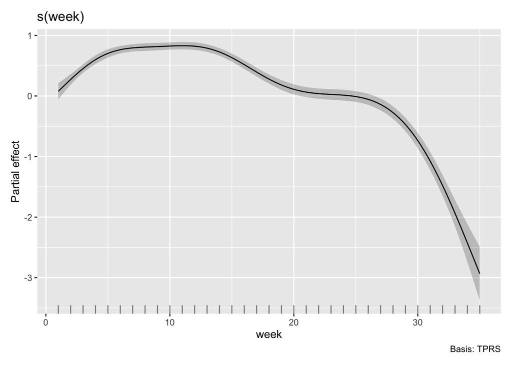

```r
m_gam |> draw()
```

**NoteTask 3**

How many effective degrees of freedom have been used by $f(\mathtt{week}_i)$?

**TipSolution**

You can use `summary()` or `overview()` for this:

```r
m_gam |> summary()
```

```
Family: Tweedie(p=1.01)
Link function: log

Formula:
fat ~ s(week)

Parametric coefficients:
            Estimate Std. Error t value Pr(>|t|)
(Intercept) -1.19627    0.02122  -56.37   <2e-16 ***
---
Signif. codes:  0 '***' 0.001 '**' 0.01 '*' 0.05 '.' 0.1 ' ' 1

Approximate significance of smooth terms:
          edf Ref.df     F p-value
s(week) 7.954  8.664 134.2  <2e-16 ***
---
Signif. codes:  0 '***' 0.001 '**' 0.01 '*' 0.05 '.' 0.1 ' ' 1

R-sq.(adj) =  0.983   Deviance explained = 98.2%
-ML = -57.183  Scale est. = 0.0026711  n = 35
```

```r
m_gam |> overview()
```

```
Generalized Additive Model with 2 terms

  term      type           k   edf ref.edf statistic p.value
  <chr>     <chr>      <dbl> <dbl>   <dbl>     <dbl> <chr>
1 Intercept parametric    NA  1       1        -56.4 <0.001
2 s(week)   TPRS           9  7.95    8.66     134.  <0.001
```

But *gratia* also provides a simple extractor function, `edf()`, for this task.

```r
m_gam |> edf()
```

```
# A tibble: 1 × 2
  .smooth  .edf
  <chr>   <dbl>
1 s(week)  7.95
```

Finally, let’s compare the fits of the two models. We start by computing the conditional values for each model, conditioning on `week`

```r
cond_glm <- m_glm |>
  conditional_values(
    condition = "week"
  )
cond_gam <- m_gam |>
  conditional_values(
    condition = "week"
  )
```

Next we need to bind these together and add a column indicating which model is which

```r
cond_vals <- cond_glm |>
  bind_rows(cond_gam) |>
  mutate(
    model = factor(
      rep(c("GLM", "GAM"), each = nrow(cond_glm))
    )
  )

cond_vals
```

```
# A tibble: 200 × 7
    .row  week .fitted    .se .lower_ci .upper_ci model
   <int> <dbl>   <dbl>  <dbl>     <dbl>     <dbl> <fct>
 1     1  1      0.221 0.133      0.170     0.287 GLM
 2     2  1.34   0.285 0.110      0.230     0.354 GLM
 3     3  1.69   0.344 0.0937     0.286     0.413 GLM
 4     4  2.03   0.397 0.0810     0.339     0.465 GLM
 5     5  2.37   0.445 0.0711     0.387     0.511 GLM
 6     6  2.72   0.488 0.0632     0.431     0.552 GLM
 7     7  3.06   0.526 0.0569     0.471     0.588 GLM
 8     8  3.40   0.560 0.0519     0.506     0.620 GLM
 9     9  3.75   0.590 0.0480     0.537     0.648 GLM
10    10  4.09   0.616 0.0449     0.565     0.673 GLM
# ℹ 190 more rows
```

Finally, we can plot the two fits

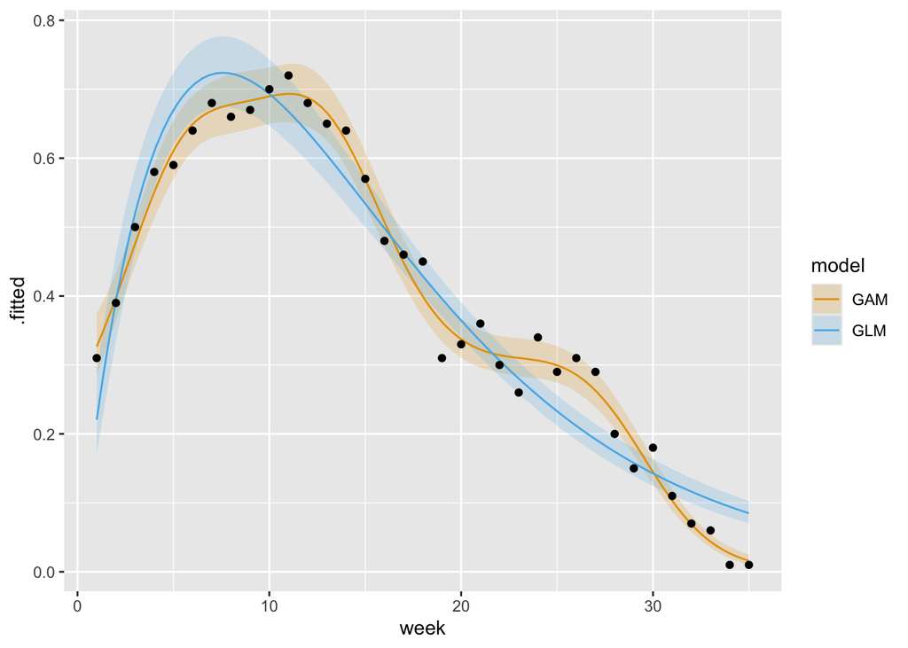

```r
cond_vals |>
  ggplot(
    aes(x = week, y = .fitted, group = model, colour = model)
  ) +
  geom_ribbon(
    aes(x = week, ymin = .lower_ci, ymax = .upper_ci, fill = model),
    inherit.aes = FALSE, alpha = 0.2
  ) +
  geom_line() +
  geom_point(
    data = lactation,
    aes(x = week, y = fat), inherit.aes = FALSE
  ) +
  ggokabeito::scale_colour_okabe_ito() +
  ggokabeito::scale_fill_okabe_ito()
```